# cp2021-F06-Q01

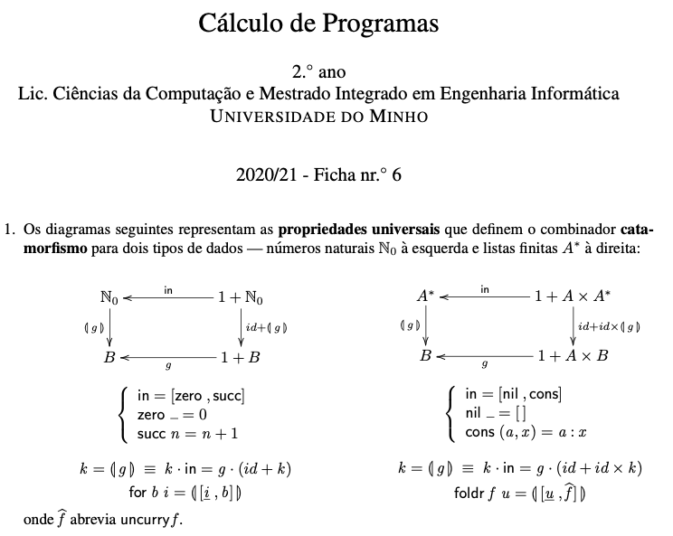

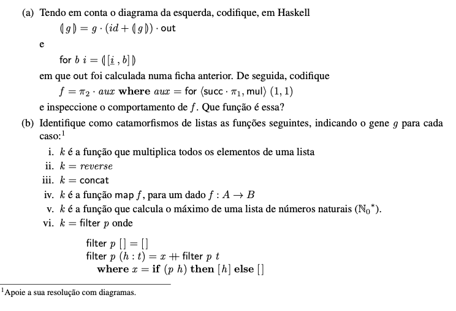

### Resolução (a)

$\def\cata#1{\mathopen{(\!|}#1\mathclose{|\!)}}\def\kons#1{\underline{#1}}$ $\cata{g} = g . (id + \cata{g}) . out$

{ ‘Shunt-left’, **lei (33)** }

$\equiv \cata{g} . in = g . (id + \cata{g})$

{ def. in, def-$+$, **lei (21)** }

$\equiv \cata{g} . [zero, succ] = g . [i_1 . id, i_2 . \cata{g}]$

{ fusão-$+$, **lei (20)**; natural-id, **lei (1)** }

$\equiv [ \cata{g} . zero, \cata{g} . succ] = [g . i_1, g . i_2 . \cata{g}]$

{ eq-$+$, **lei (27)** }

$\equiv \cata{g} . zero = g . i_1$ ; $\cata{g} . succ = g . i_2 . \cata{g}$

{ igualdade extensional, **lei (71)** }

$\equiv (\cata{g} . zero) \ a = (g . i_1) \ a$ ; $(\cata{g} . succ) \ b = (g . i_2 . \cata{g}) \ b$

{ def-comp, **lei (72)** }

$\equiv \cata{g} \ (zero \ a) = g \ (i_1 \ a)$ ; $\cata{g} \ (succ \ b) = g (i_2 (\cata{g}) \ b))$

{ def. zero; def. succ }

$\equiv \cata{g} \ 0 = g \ (i_1 \ ())$ ; $\cata{g} \ (b + 1) = g \ (i_2 \ (\cata{g} \ b))$

### Haskell

```haskell
-- loading Cp.hs
:opt no-lint
:load ../src/Cp.hs
:set -XNPlusKPatterns
```

```haskell
cata g 0 = g . Left $ ()
cata g (b + 1) = g . Right . cata g $ b

-- type checking

:t cata

-- testing with g = [const 0,(3+)]

cata (either (const 0) (3+)) 5
```

cata :: forall a b. Integral a => (Either () b -> b) -> a -> b

```
15
```

```haskell
for b i = cata (either (const i) b)

-- type checking

:t for
```

for :: forall a b. Integral a => (b -> b) -> b -> a -> b

```haskell
f = p2 . aux where aux = for (split (succ . p1) mul) (1,1)

-- type checking

:t f
```

f :: forall a c. (Integral a, Num c, Enum c) => a -> c

```haskell
f 7 -- factorial
```

```
5040
```

### Resolução (b)

Seja $k = foldr \ f \ u$.

$k = \cata{[\underline{u},\hat{f}]} \equiv k . in = g . (id + id \times k)$

{ def. in, def-$+$, **lei (21)** }

$\equiv k . [nil, cons] = g . [i_1 . id, i_2 . (id \times k)]$

{ fusão-$+$, **lei (20)**; natural-id, **lei (1)** }

$\equiv [k . nil, k . cons] = [g . i_1, g . i_2 . (id \times k)]$

{ eq-$+$, **lei (27)** }

$\equiv k . nil = g . i_1; k . cons = g . i_2 . (id \times k)$

{ igualdade extensional, **lei (71)** }

$\equiv (k . nil) \ a = (g . i_1) \ a; (k . cons) \ (a,b) = (g . i_2 . (id \times k)) \ (a,b)$

{ def-comp, **lei (72)** }

$\equiv k \ (nil \ a) = g \ (i_1 \ a); k (cons \ (a,b)) = g \ (i_2 \ (id \times k) \ (a,b))$

{ def. nil; def. cons; def-$\times$, **lei (77)**; natural-id, **lei (1)** }

$\equiv k \ [] = g \ (i_1 \ a); k (a \ : \ b) = g \ (i_2 \ (a, k a))$

```haskell
cata' g [] = g . i1 $ ()
cata' g (a:b) = g . i2 $ (a, cata' g b)

-- type checking

:t cata'
```

cata' :: forall a b. (Either () (a, b) -> b) -> [a] -> b

```haskell
foldr f u = cata' (either (const u) (uncurry f))

-- type checking

:t foldr
```

foldr :: forall a b. (a -> b -> b) -> b -> [a] -> b

```haskell
-- (i)

-- type checking and testing with g = [1,mul]

:t cata' (either (const 1) mul)

cata' (either (const 1) mul) [2,3,4,5,6]

-- type checking and testing with f = (*) and u = 1

:t foldr (*) 1

foldr (*) 1 [2,3,4,5,6]

:t uncurry (*)
```

cata' (either (const 1) mul) :: forall b. Num b => [b] -> b

```
720
```

foldr (*) 1 :: forall b. Num b => [b] -> b

```
720
```

uncurry (*) :: forall c. Num c => (c, c) -> c

```haskell
-- (ii) k = reverse

:t foldr (\a b -> b ++ [a]) []

cata' (either (const []) (\(a,b) -> b ++ [a])) [2,3,4,5,1]

foldr (\a b -> b ++ [a]) [] [2,3,4,5,1]
```

foldr (\a b -> b ++ [a]) [] :: forall a. [a] -> [a]

```
[1,5,4,3,2]
```

```
[1,5,4,3,2]
```

```haskell
-- (iii) k = concat

:t foldr (++) []

foldr (++) [] [[1,2,3],[2,3,4]]
```

foldr (++) [] :: forall a. [[a]] -> [a]

```
[1,2,3,2,3,4]
```

```haskell
-- (iv) k = map f

map' f = foldr (\a b -> f a : b) []
:t map'

map' (3*) [2,3,4]
```

map' :: forall t a. (t -> a) -> [t] -> [a]

```
[6,9,12]
```

```haskell
-- (v) k = maximum

maximum = foldr max 0
:t maximum

maximum [2,3,7,4,1,5]
```

maximum :: forall b. (Ord b, Num b) => [b] -> b

```
7
```

```haskell
-- (vi) k = filter p

filter' p = foldr (\a b -> if p a then a:b else b) []
:t filter'

filter' (>=3) [2,3,4,7,1,1,3]
```

filter' :: forall a. (a -> Bool) -> [a] -> [a]

```
[3,4,7,3]
```